# Reproducible Research-Course Project 1

Deepak Yadav

April 5, 2017

Introduction

It is now possible to collect a large amount of data about personal movement using activity monitoring devices such as a Fitbit, Nike Fuelband, or Jawbone Up. These type of devices are part of the “quantified self” movement - a group of enthusiasts who take measurements about themselves regularly to improve their health, to find patterns in their behavior, or because they are tech geeks. But these data remain under-utilized both because the raw data are hard to obtain and there is a lack of statistical methods and software for processing and interpreting the data.

This assignment makes use of data from a personal activity monitoring device. This device collects data at 5 minute intervals through out the day. The data consists of two months of data from an anonymous individual collected during the months of October and November, 2012 and include the number of steps taken in 5 minute intervals each day.

The data for this assignment can be downloaded from the course web site:

Dataset: Activity monitoring data [52K] The variables included in this dataset are:

.steps: Number of steps taking in a 5-minute interval (missing values are coded as NA) .date: The date on which the measurement was taken in YYYY-MM-DD format .interval: Identifier for the 5-minute interval in which measurement was taken

```r
if(!file.exists("./data")){dir.create("./data")}
fileUrl       <- "https://d396qusza40orc.cloudfront.net/repdata%2Fdata%2Factivity.zip"
download.file(fileUrl,destfile = "./data/Dataset.zip")
unzip(zipfile = "./data/Dataset.zip",exdir = "./data")

activity      <- read.csv("./data/activity.csv",header = TRUE,stringsAsFactors = FALSE)

sapply(activity,mode)
```

```
##       steps        date    interval
##   "numeric" "character"   "numeric"
```

```r
activity$dateTime  <- as.POSIXct(activity$date, format="%Y-%m-%d")
```

Q1:What is mean total number of steps taken per day?

For this part of the assignment, you can ignore the missing values in the dataset.

1a:Calculate the total number of steps taken per day 1b: Make a histogram of the total number of steps taken each day

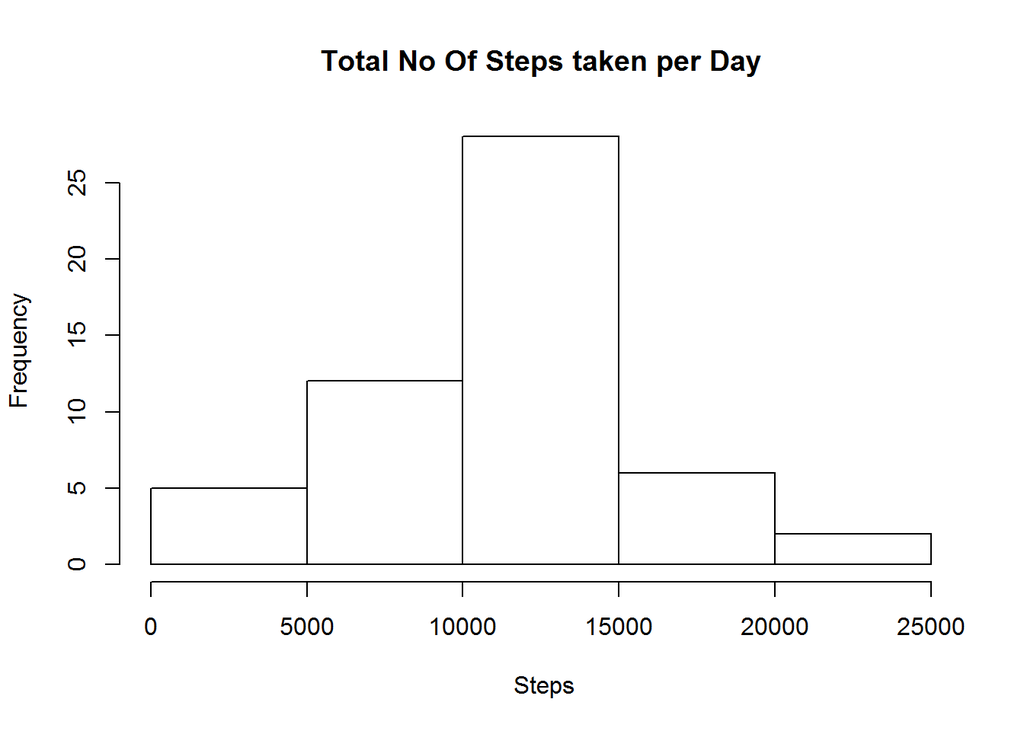

```r
    activityClean<- activity[!is.na(activity$steps),]
    aggregateSteps<- aggregate(activityClean$steps ~ activityClean$date,FUN=sum)
    #t<- tapply(activityClean$steps,INDEX = activityClean$date,FUN = sum)
    colnames(aggregateSteps)<-c("Date","Steps")
    ##png("./data/plot1.png")
    hist(aggregateSteps$Steps,xlab = " Steps",freq = TRUE,main = "Total No Of Steps taken per Day")
```

```r
    ##dev.off()
```

1c:Calculate and report the mean and median of the total number of steps taken per day.

```r
    meanSteps<- mean(aggregateSteps$Steps)
    medianSteps<- median(aggregateSteps$Steps)
    meanSteps
```

```
## [1] 10766.19
```

```
[1] 10766.19
The average number of steps taken each day was 10766.19 steps.
```

```r
    medianSteps
```

```
## [1] 10765
```

```
[1] 10765

The median number of steps taken each day was 10765 steps.
```

Q2:What is the average daily activity pattern?

Q2a:Make a time series plot (i.e. type = “l”) of the 5-minute interval (x-axis) and the average number of steps taken, averaged across all days (y-axis)

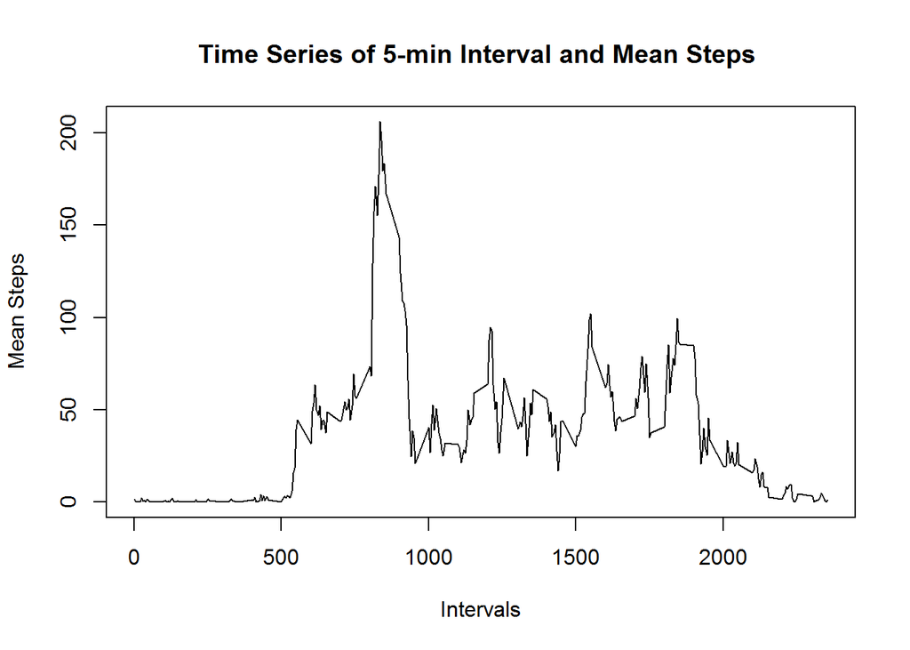

```r
    intervalClean              <- activity[!is.na(activity$interval),]
    aggregateInterval          <- aggregate(intervalClean$steps ~ intervalClean$interval,
                                  intervalClean,mean)
    colnames(aggregateInterval)<-c("Interval","Steps")
    ##png("./data/plot2.png")
    plot(aggregateInterval$Interval,aggregateInterval$Steps,type = "l",xlab = "Intervals",ylab = "Mean Steps",main = "Time Series of 5-min Interval and Mean Steps ")
```

```r
    ##dev.off()
```

Q2b:Which 5-minute interval, on average across all the days in the dataset, contains the maximum number of steps?

```r
    maxStepsInterval<- aggregateInterval[aggregateInterval$Steps ==  max(aggregateInterval$Steps),1]
```

[1] 835

Q3:Imputing missing values

```r
    sapply(activity,function(x) sum(is.na(x)))
```

```
##    steps     date interval dateTime
##     2304        0        0        0
```

The total number of missing values in the dataset (i.e. the total number of rows with NAs) = 2304

[output not shown]

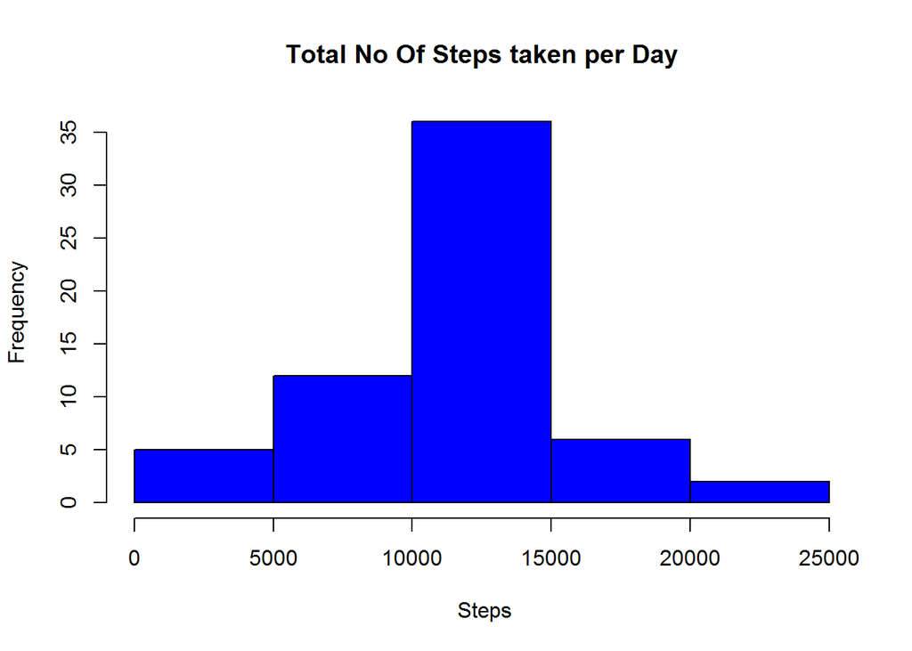

```r
    aggSteps           <-aggregate(activity2$steps~activity2$date,FUN=sum)
    colnames(aggSteps) <-c("Date","Steps")
    ##png("./data/plot3.png")
    hist(aggSteps$Steps,xlab = " Steps",main = "Total No Of Steps taken per Day",col = "blue")
```

```r
    ##dev.off()
```

```r
    meanSteps<-mean(aggSteps$Steps)
    meanSteps
```

```
## [1] 10766.19
```

[output not shown]

The impact of imputing missing data with the average number of steps in the same 5-min interval is that both the mean and the median are same : 10766.19

Q4:Are there differences in activity patterns between weekdays and weekends?

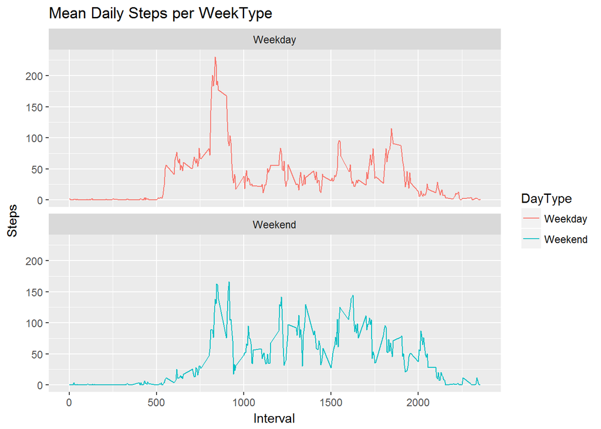

```r
    activity2$date      <- as.Date(activity2$date)

    activity2$dayType   <- ifelse(weekdays(activity2$date) =="Saturday"|weekdays(activity2$date) == "Sunday","Weekend","Weekday")
    aggStepsPerWeekType <-aggregate(activity2$steps ~ activity2$dayType+activity2$interval,activity2,FUN=mean)
    colnames(aggStepsPerWeekType) <-c("DayType","Interval","Steps")
    library(ggplot2)
    ##png("./data/plot4.png")
    plot<- ggplot(data = aggStepsPerWeekType,aes(Interval,Steps,color=DayType))+geom_line()+facet_wrap(~DayType,ncol = 1,nrow = 2)+labs(title ="Mean Daily Steps per WeekType",x = "Interval",y= "Steps")

    print(plot)
```

```r
    ##dev.off()
```